# Final Presentation

May 10, 2023 @ 06:04 PM

## Packages Used

I used tidyverse for manipulating and looking at my data for the needed information for ideas.

```r
library(tidyverse)
```

I used ggplot2 in order to graph my data for the interpreations that I made.

```r
library(ggplot2)
```

## Smoking Dataset

I acquired my dataset from the website Kaggle. This website can be used to acquire multiple kinds and varities of datasets. The specific link is as follows. [Smoking Dataset from UK](https://www.kaggle.com/datasets/utkarshx27/smoking-dataset-from-uk). The dataset was last modified 15 hours ago at the time of writing (5/10/2023). But, given the subject this information is likely to change in the future.

**Variables in the Dataset:**

- ‘gender’: Gender with levels Female and Male
- ‘age’ : Age of the participants
- ‘marital_status’ : Marital status with levels which are Divorced, Married, Separated, Single and Windowed
- ‘highest_qualification’ : Highest Education Levels
- ‘nationality’ : The participants identified nationality varies from British, English, Irish, SCottish, Welseh, Ohter, Refused, and Unknown
- ‘ethnicity’ : The participants ethnicity with levels those being Asian, Black, Chinese, Mixed, White, and Refused/Unknown
- ‘gross_income’ : Level of income before taxes which was set by varying income levels generally in 5,200 pounds (roughly equivalent to American Dollars) increments
- ‘region’ : From what region they resided in
- ‘smoke’ : Yes or no to current smoking status
- ‘amt_weekends’ : Amount of cigarettes smoked per day during the weekend
- ‘amt_weekdays’ :Amount of cigarettes smoked per day during the weekdays
- ‘type’ :Type of cigarette smoked with levels. These being rolled, mainly packets, and mainly hand-rolled

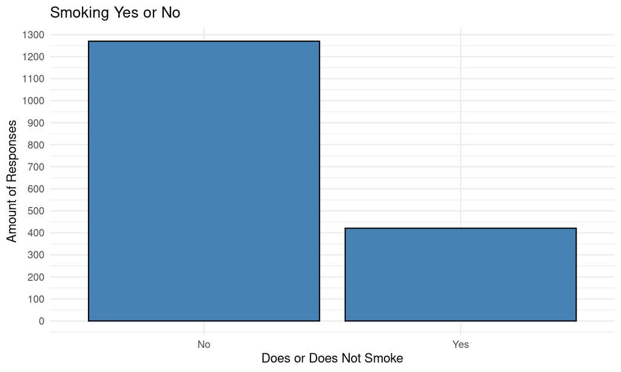

The first question that I had after using glimpse to view the data was under the smoke variable was there only yes responses or yes and no responses. So, I created this simple plot in order to find out that answer.

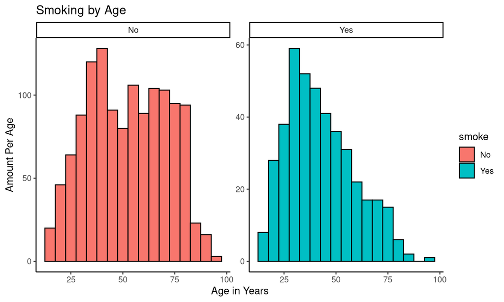

With the previous information in mind I deicded to see the breakdown of those who did and did not smoke by age. As can be seen there is a spike of smokers around ages 25-40 which then decreases with age.